# پروژه‌ی شماره صفر - هوش مصنوعی

مجید فریدفر - 810199569

```python
import pandas as pd
import numpy as np
import matplotlib as plt

import timeit
import scipy as sp
```

# سوال اول

```python
df = pd.read_csv('train.csv')
df
```

|  | age | workclass | fnlwgt | education | education-num | marital-status | occupation | relationship | race | sex | capital-gain | capital-loss | hours-per-week | native-country | salary |
| --- | --- | --- | --- | --- | --- | --- | --- | --- | --- | --- | --- | --- | --- | --- | --- |
| 0 | 39 | State-gov | 77516 | Bachelors | 13 | Never-married | Adm-clerical | Not-in-family | White | Male | 2174 | 0 | 40 | United-States | <=50K |
| 1 | 50 | Self-emp-not-inc | 83311 | Bachelors | 13 | Married-civ-spouse | Exec-managerial | Husband | White | Male | 0 | 0 | 13 | United-States | <=50K |
| 2 | 38 | Private | 215646 | HS-grad | 9 | Divorced | Handlers-cleaners | Not-in-family | White | Male | 0 | 0 | 40 | United-States | <=50K |
| 3 | 53 | Private | 234721 | 11th | 7 | Married-civ-spouse | Handlers-cleaners | Husband | Black | Male | 0 | 0 | 40 | United-States | <=50K |
| 4 | 28 | Private | 338409 | Bachelors | 13 | Married-civ-spouse | Prof-specialty | Wife | Black | Female | 0 | 0 | 40 | Cuba | <=50K |
| ... | ... | ... | ... | ... | ... | ... | ... | ... | ... | ... | ... | ... | ... | ... | ... |
| 29820 | 48 | Local-gov | 127921 | Bachelors | 13 | Married-civ-spouse | Prof-specialty | Husband | White | Male | 0 | 0 | 40 | United-States | <=50K |
| 29821 | 32 | Private | 42617 | Some-college | 10 | Divorced | Prof-specialty | Not-in-family | White | Female | 0 | 0 | 30 | United-States | <=50K |
| 29822 | 47 | Local-gov | 191389 | HS-grad | 9 | Divorced | Adm-clerical | Unmarried | White | Female | 0 | 0 | 35 | United-States | <=50K |
| 29823 | 38 | Private | 187983 | Prof-school | 15 | Married-civ-spouse | Sales | Wife | White | Female | 0 | 0 | 40 | United-States | <=50K |
| 29824 | 18 | Private | 215110 | HS-grad | 9 | Never-married | Handlers-cleaners | Own-child | Black | Male | 0 | 0 | 40 | United-States | <=50K |

29825 rows × 15 columns

```python
df.describe()
```

|  | age | fnlwgt | education-num | capital-gain | capital-loss | hours-per-week |
| --- | --- | --- | --- | --- | --- | --- |
| count | 29825.000000 | 2.982500e+04 | 29825.000000 | 29825.000000 | 29825.000000 | 29825.000000 |
| mean | 38.581425 | 1.897389e+05 | 10.079229 | 1094.586052 | 86.476513 | 40.434334 |
| std | 13.652005 | 1.053738e+05 | 2.571678 | 7485.908646 | 401.195078 | 12.308174 |
| min | 17.000000 | 1.228500e+04 | 1.000000 | 0.000000 | 0.000000 | 1.000000 |
| 25% | 28.000000 | 1.178490e+05 | 9.000000 | 0.000000 | 0.000000 | 40.000000 |
| 50% | 37.000000 | 1.785170e+05 | 10.000000 | 0.000000 | 0.000000 | 40.000000 |
| 75% | 48.000000 | 2.368790e+05 | 12.000000 | 0.000000 | 0.000000 | 45.000000 |
| max | 90.000000 | 1.484705e+06 | 16.000000 | 99999.000000 | 4356.000000 | 99.000000 |

این تابع موارد زیر را برای هر ستون عددی نشان میدهد:  
1. تعداد مقادیر  
2. میانگین  
3. انحراف معیار  
4. کم ترین مقدار  
5. چارک اول  
6. چارک دوم  
7. جارک سوم  
8. بیشترین مقدار  
* همچنین با وارد کردن include = 'all' میتوانیم اطلاعات مربوط به ستون های غیرعددی را هم مشاهده کنیم.

```python
df.tail()
```

|  | age | workclass | fnlwgt | education | education-num | marital-status | occupation | relationship | race | sex | capital-gain | capital-loss | hours-per-week | native-country | salary |
| --- | --- | --- | --- | --- | --- | --- | --- | --- | --- | --- | --- | --- | --- | --- | --- |
| 29820 | 48 | Local-gov | 127921 | Bachelors | 13 | Married-civ-spouse | Prof-specialty | Husband | White | Male | 0 | 0 | 40 | United-States | <=50K |
| 29821 | 32 | Private | 42617 | Some-college | 10 | Divorced | Prof-specialty | Not-in-family | White | Female | 0 | 0 | 30 | United-States | <=50K |
| 29822 | 47 | Local-gov | 191389 | HS-grad | 9 | Divorced | Adm-clerical | Unmarried | White | Female | 0 | 0 | 35 | United-States | <=50K |
| 29823 | 38 | Private | 187983 | Prof-school | 15 | Married-civ-spouse | Sales | Wife | White | Female | 0 | 0 | 40 | United-States | <=50K |
| 29824 | 18 | Private | 215110 | HS-grad | 9 | Never-married | Handlers-cleaners | Own-child | Black | Male | 0 | 0 | 40 | United-States | <=50K |

این تابع پنج سطر آخر دیتا ست را نمایش میدهد. البته میتوان این عدد را تغییر داد:  
df.tail(n=10)

```python
df.head()
```

|  | age | workclass | fnlwgt | education | education-num | marital-status | occupation | relationship | race | sex | capital-gain | capital-loss | hours-per-week | native-country | salary |
| --- | --- | --- | --- | --- | --- | --- | --- | --- | --- | --- | --- | --- | --- | --- | --- |
| 0 | 39 | State-gov | 77516 | Bachelors | 13 | Never-married | Adm-clerical | Not-in-family | White | Male | 2174 | 0 | 40 | United-States | <=50K |
| 1 | 50 | Self-emp-not-inc | 83311 | Bachelors | 13 | Married-civ-spouse | Exec-managerial | Husband | White | Male | 0 | 0 | 13 | United-States | <=50K |
| 2 | 38 | Private | 215646 | HS-grad | 9 | Divorced | Handlers-cleaners | Not-in-family | White | Male | 0 | 0 | 40 | United-States | <=50K |
| 3 | 53 | Private | 234721 | 11th | 7 | Married-civ-spouse | Handlers-cleaners | Husband | Black | Male | 0 | 0 | 40 | United-States | <=50K |
| 4 | 28 | Private | 338409 | Bachelors | 13 | Married-civ-spouse | Prof-specialty | Wife | Black | Female | 0 | 0 | 40 | Cuba | <=50K |

این تابع پنج سطر اول دیتا ست را نمایش میدهد. البته میتوان این عدد را تغییر داد:  
df.head(n=10)

```python
df.info()
```

```
<class 'pandas.core.frame.DataFrame'>
RangeIndex: 29825 entries, 0 to 29824
Data columns (total 15 columns):
 #   Column          Non-Null Count  Dtype
---  ------          --------------  -----
 0   age             29825 non-null  int64
 1   workclass       28154 non-null  object
 2   fnlwgt          29825 non-null  int64
 3   education       29825 non-null  object
 4   education-num   29825 non-null  int64
 5   marital-status  29825 non-null  object
 6   occupation      28149 non-null  object
 7   relationship    29825 non-null  object
 8   race            29825 non-null  object
 9   sex             29825 non-null  object
 10  capital-gain    29825 non-null  int64
 11  capital-loss    29825 non-null  int64
 12  hours-per-week  29825 non-null  int64
 13  native-country  29288 non-null  object
 14  salary          29825 non-null  object
dtypes: int64(6), object(9)
memory usage: 3.4+ MB
```

این تابع برای هر ستون، این موارد را نشان میدهد:  
1. نام ستون  
2. تعداد مقادیرِ وارد شده  
3. نوع ستون (عددی یا غیر عددی)  
همچنین علاوه بر این اطلاعات، اطلاعات زیر را هم به صورت جداگانه به ما میدهد:  
1. تعداد داده های ثبت شده (سطرها)  
2. تعداد ستون ها  
3. تعداد ستون های عددی  
4. تعداد ستون های غیر عددی  
5. حجم اشغالی دیتاست

# سوال دوم

تعداد ستون های عددی و غیر عددی و همینطور نوع هر ستون، در بخش آخر سوال قبلی نمایش داده شده است.  
عددی: 6 تا - غیر عددی: 9 تا  
* یک کپی از دیتاست نگه میداریم تا دیتاهای صالی خراب نشوند.

```python
sex = {'Female': 0, 'Male': 1}

df_original = df.copy()

df['sex'].replace(sex, inplace=True)

df
```

|  | age | workclass | fnlwgt | education | education-num | marital-status | occupation | relationship | race | sex | capital-gain | capital-loss | hours-per-week | native-country | salary |
| --- | --- | --- | --- | --- | --- | --- | --- | --- | --- | --- | --- | --- | --- | --- | --- |
| 0 | 39 | State-gov | 77516 | Bachelors | 13 | Never-married | Adm-clerical | Not-in-family | White | 1 | 2174 | 0 | 40 | United-States | <=50K |
| 1 | 50 | Self-emp-not-inc | 83311 | Bachelors | 13 | Married-civ-spouse | Exec-managerial | Husband | White | 1 | 0 | 0 | 13 | United-States | <=50K |
| 2 | 38 | Private | 215646 | HS-grad | 9 | Divorced | Handlers-cleaners | Not-in-family | White | 1 | 0 | 0 | 40 | United-States | <=50K |
| 3 | 53 | Private | 234721 | 11th | 7 | Married-civ-spouse | Handlers-cleaners | Husband | Black | 1 | 0 | 0 | 40 | United-States | <=50K |
| 4 | 28 | Private | 338409 | Bachelors | 13 | Married-civ-spouse | Prof-specialty | Wife | Black | 0 | 0 | 0 | 40 | Cuba | <=50K |
| ... | ... | ... | ... | ... | ... | ... | ... | ... | ... | ... | ... | ... | ... | ... | ... |
| 29820 | 48 | Local-gov | 127921 | Bachelors | 13 | Married-civ-spouse | Prof-specialty | Husband | White | 1 | 0 | 0 | 40 | United-States | <=50K |
| 29821 | 32 | Private | 42617 | Some-college | 10 | Divorced | Prof-specialty | Not-in-family | White | 0 | 0 | 0 | 30 | United-States | <=50K |
| 29822 | 47 | Local-gov | 191389 | HS-grad | 9 | Divorced | Adm-clerical | Unmarried | White | 0 | 0 | 0 | 35 | United-States | <=50K |
| 29823 | 38 | Private | 187983 | Prof-school | 15 | Married-civ-spouse | Sales | Wife | White | 0 | 0 | 0 | 40 | United-States | <=50K |
| 29824 | 18 | Private | 215110 | HS-grad | 9 | Never-married | Handlers-cleaners | Own-child | Black | 1 | 0 | 0 | 40 | United-States | <=50K |

29825 rows × 15 columns

اینجا، ما به جای female قرار دادیم 0 و به جای male قرار دادیم 1.  
همچنین از روش زیر هم میتوانیم استفاده کنیم که برای عددی کردن بقیه ستون ها از آن استفاده میکنیم.

```python
df['workclass'] = pd.factorize(df['workclass'])[0]
df['education'] = pd.factorize(df['education'])[0]
df['marital-status'] = pd.factorize(df['marital-status'])[0]
df['occupation'] = pd.factorize(df['occupation'])[0]
df['relationship'] = pd.factorize(df['relationship'])[0]
df['race'] = pd.factorize(df['race'])[0]
df['native-country'] = pd.factorize(df['native-country'])[0]
df['salary'] = pd.factorize(df['salary'])[0]

df
```

|  | age | workclass | fnlwgt | education | education-num | marital-status | occupation | relationship | race | sex | capital-gain | capital-loss | hours-per-week | native-country | salary |
| --- | --- | --- | --- | --- | --- | --- | --- | --- | --- | --- | --- | --- | --- | --- | --- |
| 0 | 39 | 0 | 77516 | 0 | 13 | 0 | 0 | 0 | 0 | 1 | 2174 | 0 | 40 | 0 | 0 |
| 1 | 50 | 1 | 83311 | 0 | 13 | 1 | 1 | 1 | 0 | 1 | 0 | 0 | 13 | 0 | 0 |
| 2 | 38 | 2 | 215646 | 1 | 9 | 2 | 2 | 0 | 0 | 1 | 0 | 0 | 40 | 0 | 0 |
| 3 | 53 | 2 | 234721 | 2 | 7 | 1 | 2 | 1 | 1 | 1 | 0 | 0 | 40 | 0 | 0 |
| 4 | 28 | 2 | 338409 | 0 | 13 | 1 | 3 | 2 | 1 | 0 | 0 | 0 | 40 | 1 | 0 |
| ... | ... | ... | ... | ... | ... | ... | ... | ... | ... | ... | ... | ... | ... | ... | ... |
| 29820 | 48 | 4 | 127921 | 0 | 13 | 1 | 3 | 1 | 0 | 1 | 0 | 0 | 40 | 0 | 0 |
| 29821 | 32 | 2 | 42617 | 5 | 10 | 2 | 3 | 0 | 0 | 0 | 0 | 0 | 30 | 0 | 0 |
| 29822 | 47 | 4 | 191389 | 1 | 9 | 2 | 0 | 4 | 0 | 0 | 0 | 0 | 35 | 0 | 0 |
| 29823 | 38 | 2 | 187983 | 10 | 15 | 1 | 5 | 2 | 0 | 0 | 0 | 0 | 40 | 0 | 0 |
| 29824 | 18 | 2 | 215110 | 1 | 9 | 0 | 2 | 3 | 1 | 1 | 0 | 0 | 40 | 0 | 0 |

29825 rows × 15 columns

# سوال سوم

```python
df_original.isnull().sum(axis = 0)
```

```
age                  0
workclass         1671
fnlwgt               0
education            0
education-num        0
marital-status       0
occupation        1676
relationship         0
race                 0
sex                  0
capital-gain         0
capital-loss         0
hours-per-week       0
native-country     537
salary               0
dtype: int64
```

همین طور که مشاهده میشود، در سه تا از ستون ها مقادیر NaN داریم.  
اما نکته ای که وجود دارد این است که تمام این ویژگی ها از نوع دسته ای اند. پس ایده ی پر کردن آن ها با مقدار میانگین ایده ی خوبی نخواهد بود. و همچنین، چون تعداد این NaN ها برای هر ستون، زیاد نیست، حذف ستون هم کار خوبی نخواهد بود.  
اما در ادامه، نحوه ی پر کردن این مقادیر با مقدار میانگین آمده است (در قسمت کد کامنت شده):

```python
# df['workclass'].fillna(value=df['workclass'].mean(), inplace=True)
# df['occupation'].fillna(value=df['occupation'].mean(), inplace=True)
# df['native-country'].fillna(value=df['native-country'].mean(), inplace=True)
```

برای رفع این مشکل، بهتر است دنبال راه حل دیگری باشیم. به این منظور، بررسی میکنیم که برای هر کدام از این سه ستون، کدام مقدار، بیشتر در آن تکرار شده است:

```python
df_original['workclass'].value_counts()
```

```
Private             20781
Self-emp-not-inc     2349
Local-gov            1911
State-gov            1181
Self-emp-inc         1032
Federal-gov           882
Without-pay            13
Never-worked            5
Name: workclass, dtype: int64
```

```python
df_original['occupation'].value_counts()
```

```
Prof-specialty       3773
Craft-repair         3759
Exec-managerial      3706
Adm-clerical         3491
Sales                3356
Other-service        3029
Machine-op-inspct    1839
Transport-moving     1464
Handlers-cleaners    1244
Farming-fishing       906
Tech-support          849
Protective-serv       582
Priv-house-serv       143
Armed-Forces            8
Name: occupation, dtype: int64
```

```python
df_original['native-country'].value_counts()
```

```
United-States                 26713
Mexico                          596
Philippines                     174
Germany                         122
Canada                          115
Puerto-Rico                     112
El-Salvador                      95
India                            94
England                          87
Cuba                             86
South                            76
Jamaica                          73
China                            68
Vietnam                          62
Italy                            62
Dominican-Republic               61
Guatemala                        60
Japan                            56
Poland                           56
Columbia                         54
Taiwan                           48
Haiti                            40
Iran                             40
Portugal                         33
Nicaragua                        31
Peru                             28
Greece                           28
France                           27
Ecuador                          25
Ireland                          23
Thailand                         18
Cambodia                         18
Trinadad&Tobago                  16
Hong                             15
Laos                             15
Yugoslavia                       14
Hungary                          12
Honduras                         12
Outlying-US(Guam-USVI-etc)       11
Scotland                         11
Holand-Netherlands                1
Name: native-country, dtype: int64
```

همان طور که مشاهده میشود، در هر کدام از ستون ها، شمار پر تعداد ترین مقدار به شرح زیر است:  
برای ستون workclass مقدار Private که 20781 بار تکرار شده.  
برای ستون occupation تقریبا مقداری یافت نمیشود، که بتوان با اختلاف خوبی، به عنوان پرتکرارترین داده در نظر گرفت. برای همین از پر کردن NaN های این ستون صرف نظر میکنیم.  
برای ستون native-country مقدار United-States با اختلاف، پرتکرار ترین داده است.  
حالا برای پر کردن NaN های ستون های workclass و native-country از پر تکرار ترین داده ی همان ستون استفاده میکنیم:  
برای احتیاط همین روند را برای ستون occupation هم اعمال میکنیم:

```python
df['workclass'].replace(-1, df['workclass'].mode()[0], inplace=True)
df_original['workclass'].fillna(df_original['workclass'].mode()[0], inplace=True)

df['occupation'].replace(-1, df['occupation'].mode()[0], inplace=True)
df_original['occupation'].fillna(df_original['occupation'].mode()[0], inplace=True)

df['native-country'].replace(-1, df['native-country'].mode()[0], inplace=True)
df_original['native-country'].fillna(df_original['native-country'].mode()[0], inplace=True)

df
```

|  | age | workclass | fnlwgt | education | education-num | marital-status | occupation | relationship | race | sex | capital-gain | capital-loss | hours-per-week | native-country | salary |
| --- | --- | --- | --- | --- | --- | --- | --- | --- | --- | --- | --- | --- | --- | --- | --- |
| 0 | 39 | 0 | 77516 | 0 | 13 | 0 | 0 | 0 | 0 | 1 | 2174 | 0 | 40 | 0 | 0 |
| 1 | 50 | 1 | 83311 | 0 | 13 | 1 | 1 | 1 | 0 | 1 | 0 | 0 | 13 | 0 | 0 |
| 2 | 38 | 2 | 215646 | 1 | 9 | 2 | 2 | 0 | 0 | 1 | 0 | 0 | 40 | 0 | 0 |
| 3 | 53 | 2 | 234721 | 2 | 7 | 1 | 2 | 1 | 1 | 1 | 0 | 0 | 40 | 0 | 0 |
| 4 | 28 | 2 | 338409 | 0 | 13 | 1 | 3 | 2 | 1 | 0 | 0 | 0 | 40 | 1 | 0 |
| ... | ... | ... | ... | ... | ... | ... | ... | ... | ... | ... | ... | ... | ... | ... | ... |
| 29820 | 48 | 4 | 127921 | 0 | 13 | 1 | 3 | 1 | 0 | 1 | 0 | 0 | 40 | 0 | 0 |
| 29821 | 32 | 2 | 42617 | 5 | 10 | 2 | 3 | 0 | 0 | 0 | 0 | 0 | 30 | 0 | 0 |
| 29822 | 47 | 4 | 191389 | 1 | 9 | 2 | 0 | 4 | 0 | 0 | 0 | 0 | 35 | 0 | 0 |
| 29823 | 38 | 2 | 187983 | 10 | 15 | 1 | 5 | 2 | 0 | 0 | 0 | 0 | 40 | 0 | 0 |
| 29824 | 18 | 2 | 215110 | 1 | 9 | 0 | 2 | 3 | 1 | 1 | 0 | 0 | 40 | 0 | 0 |

29825 rows × 15 columns

## روش پر کردن خانه های خالی با مقدار میانگین

مزایا:  
1. این امر، باعث تغییر میانگین کل داده ها نمیشود.  
2. در مواقعی که تعداد کمی مقدار NaN داریم، کار خوبی است چون باعث میشود مجبور نباشیم ستون را به طور کلی حذف کنیم.  
3. کار راحتی است.  
4. در صورتی که مقدار خانه‌های خالی، زیاد نباشد، تقریب خیلی خوبی برای این مقدار است.  
معایب:  
1. انحراف معیار از مقدار واقعی اش کمتر میشود.  
2. نوع توزیع داده ها عوض میشود.  
3. فقط برای داده های عددی کاربرد دارد.  
4. ممکن است (در صورتی که تعداد NaN ها برای یک ستون خیلی زیاد باشد) باعث اشتباه در بررسی وابستگی داده ای به ستون هدف بشود.

# سوال چهارم

```python
for column in df:
    print(column, ":", len(df[column].unique()), "of", df.shape[0])
```

```
age : 72 of 29825
workclass : 8 of 29825
fnlwgt : 20337 of 29825
education : 16 of 29825
education-num : 16 of 29825
marital-status : 7 of 29825
occupation : 14 of 29825
relationship : 6 of 29825
race : 5 of 29825
sex : 2 of 29825
capital-gain : 118 of 29825
capital-loss : 91 of 29825
hours-per-week : 94 of 29825
native-country : 41 of 29825
salary : 2 of 29825
```

همان طور که مشاهده میشود، مقادیر موجود در ستون fnlwgt تقریبا uniqueاند.  
چون از 29825 مورد ممکن، 20337 تا مقدار متمایز در آن قرار گرفته. یعنی از همه بیشتر. پس احتمالا این ویژگی تاثیری در تابع هدفمان ندارد و بهتر است آن را حذف کنیم.

```python
df.drop(columns='fnlwgt',axis=1, inplace=True)
df
```

|  | age | workclass | education | education-num | marital-status | occupation | relationship | race | sex | capital-gain | capital-loss | hours-per-week | native-country | salary |
| --- | --- | --- | --- | --- | --- | --- | --- | --- | --- | --- | --- | --- | --- | --- |
| 0 | 39 | 0 | 0 | 13 | 0 | 0 | 0 | 0 | 1 | 2174 | 0 | 40 | 0 | 0 |
| 1 | 50 | 1 | 0 | 13 | 1 | 1 | 1 | 0 | 1 | 0 | 0 | 13 | 0 | 0 |
| 2 | 38 | 2 | 1 | 9 | 2 | 2 | 0 | 0 | 1 | 0 | 0 | 40 | 0 | 0 |
| 3 | 53 | 2 | 2 | 7 | 1 | 2 | 1 | 1 | 1 | 0 | 0 | 40 | 0 | 0 |
| 4 | 28 | 2 | 0 | 13 | 1 | 3 | 2 | 1 | 0 | 0 | 0 | 40 | 1 | 0 |
| ... | ... | ... | ... | ... | ... | ... | ... | ... | ... | ... | ... | ... | ... | ... |
| 29820 | 48 | 4 | 0 | 13 | 1 | 3 | 1 | 0 | 1 | 0 | 0 | 40 | 0 | 0 |
| 29821 | 32 | 2 | 5 | 10 | 2 | 3 | 0 | 0 | 0 | 0 | 0 | 30 | 0 | 0 |
| 29822 | 47 | 4 | 1 | 9 | 2 | 0 | 4 | 0 | 0 | 0 | 0 | 35 | 0 | 0 |
| 29823 | 38 | 2 | 10 | 15 | 1 | 5 | 2 | 0 | 0 | 0 | 0 | 40 | 0 | 0 |
| 29824 | 18 | 2 | 1 | 9 | 0 | 2 | 3 | 1 | 1 | 0 | 0 | 40 | 0 | 0 |

29825 rows × 14 columns

# سوال پنجم

```python
men = df_original[df_original['sex'] == 'Male']
women = df_original[df_original['sex'] == 'Female']

print("Number of men:", men.shape[0])
print("Number of women:", women.shape[0])
```

```
Number of men: 19956
Number of women: 9869
```

دقت کنید که برای افرادر متاهل سه نوع حالت داریم: 1. Married-civ-spouse 2. Married-AF-spouse 3. Married-spouse-absent

```python
married_men = df_original[(df_original['sex'] == 'Male') & ((df_original['marital-status'] == 'Married-civ-spouse') |
                                                            (df_original['marital-status'] == 'Married-AF-spouse') |
                                                            (df_original['marital-status'] == 'Married-spouse-absent'))]

print("Number of married men:", married_men.shape[0])
```

```
Number of married men: 12373
```

# سوال ششم

```python
thirty_black_privates = df_original[(df_original['age'] > 30) & (df_original['race'] == 'Black') & (df_original['workclass'] == 'Private')]

print("Number of black people older than 30, who work privately:", thirty_black_privates.shape[0])
```

```
Number of black people older than 30, who work privately: 1373
```

# سوال هفتم

```python
def with_vectorization():
    bachelors = df_original[df_original['education'] == 'Bachelors']

    return bachelors['hours-per-week'].mean()

print("Mean of bachelors' hours of work:", with_vectorization())
```

```
Mean of bachelors' hours of work: 42.546669366268475
```

# سوال هشتم

```python
def without_vectorization():
    count = 0
    sum = 0

    for index, row in df_original.iterrows():
        if row['education'] == 'Bachelors':
            sum += row['hours-per-week']
            count += 1

    return (sum / count)

print("Mean of bachelors' hours of work:", without_vectorization())
```

```
Mean of bachelors' hours of work: 42.546669366268475
```

```python
print("Execution time of the way with vectorization:", timeit.timeit(with_vectorization, number=10))
print("Execution time of the way without vectorization:", timeit.timeit(without_vectorization, number=10))
```

```
Execution time of the way with vectorization: 0.07023769999977958
Execution time of the way without vectorization: 28.684451699999954
```

همان طور که مشاهده میشود، زمان 10 بار اجرا شدن این عمل با دو روش متفاوت، اختلاف فاحشی دارد!  
دلیل این اتفاق این است که متودهای آماده، به صورت بهینه پیاده سازی شده اند. به این ترتیب بار انجام یک عمل تکراری را روی هسته های مختلف پردازنده پخش میکنند و به این ترتیب موازی سازی انجام میشود. برای همین کار خیلی سریع تر انجام میشود. اما وقتی خودمان همین کار را با یک حلقه ی for انجام میدهیم، سریال بودن نحوه ی انجام آن منجر میشود که زمان اجرار خیلی افزایش پیدا بکند.

# سوال نهم

```
array([[<Axes: title={'center': 'age'}>,
        <Axes: title={'center': 'workclass'}>,
        <Axes: title={'center': 'education'}>,
        <Axes: title={'center': 'education-num'}>],
       [<Axes: title={'center': 'marital-status'}>,
        <Axes: title={'center': 'occupation'}>,
        <Axes: title={'center': 'relationship'}>,
        <Axes: title={'center': 'race'}>],
       [<Axes: title={'center': 'sex'}>,
        <Axes: title={'center': 'capital-gain'}>,
        <Axes: title={'center': 'capital-loss'}>,
        <Axes: title={'center': 'hours-per-week'}>],
       [<Axes: title={'center': 'native-country'}>,
        <Axes: title={'center': 'salary'}>, <Axes: >, <Axes: >]],
      dtype=object)
```

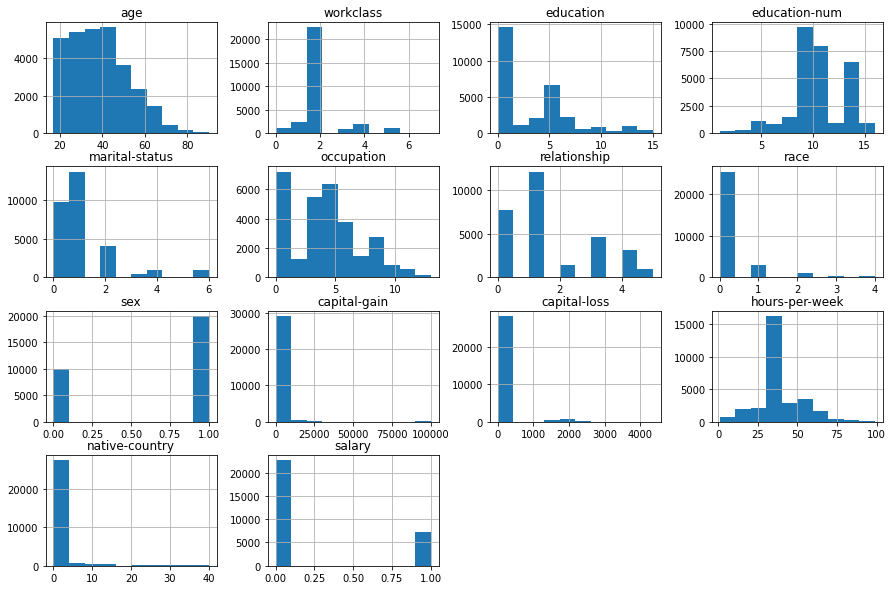

```python
df.hist(figsize=(15, 10))
```

# سوال دهم

```
array([[<Axes: title={'center': 'age'}>,
        <Axes: title={'center': 'workclass'}>,
        <Axes: title={'center': 'education'}>,
        <Axes: title={'center': 'education-num'}>],
       [<Axes: title={'center': 'marital-status'}>,
        <Axes: title={'center': 'occupation'}>,
        <Axes: title={'center': 'relationship'}>,
        <Axes: title={'center': 'race'}>],
       [<Axes: title={'center': 'sex'}>,
        <Axes: title={'center': 'capital-gain'}>,
        <Axes: title={'center': 'capital-loss'}>,
        <Axes: title={'center': 'hours-per-week'}>],
       [<Axes: title={'center': 'native-country'}>,
        <Axes: title={'center': 'salary'}>, <Axes: >, <Axes: >]],
      dtype=object)
```

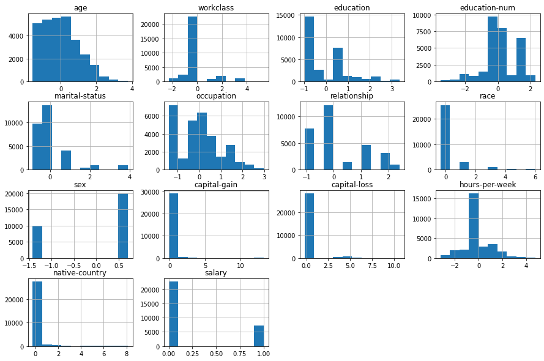

```python
normalized = df.copy()

normalized.drop('salary', axis=1, inplace=True)
normalized = (df - df.mean()) / df.std()
normalized['salary'] = df['salary']

normalized.hist(figsize=(15, 10))
```

# سوال یازدهم

```python
less_than_50k = normalized[normalized['salary'] == 0]
more_than_50k = normalized[normalized['salary'] == 1]

lt_mean = less_than_50k.mean()
lt_std = less_than_50k.std()

mt_mean = more_than_50k.mean()
mt_std = more_than_50k.std()

print("<= 50 Mean:")
print(lt_mean, "\n")
print("<= 50 Std:")
print(lt_std, "\n")
print("> 50 Mean:")
print(mt_mean, "\n")
print("> 50 Std:")
print(mt_std)
```

```
<= 50 Mean:
age              -0.130817
workclass        -0.051843
education         0.025847
education-num    -0.187560
marital-status    0.000341
occupation        0.039253
relationship      0.096514
race              0.039400
sex              -0.121698
capital-gain     -0.125991
capital-loss     -0.082596
hours-per-week   -0.128372
native-country    0.015597
salary            0.000000
dtype: float64

<= 50 Std:
age               1.027893
workclass         0.904498
education         1.012158
education-num     0.946097
marital-status    1.103968
occupation        1.007060
relationship      1.092388
race              1.051527
sex               1.035700
capital-gain      0.131465
capital-loss      0.776095
hours-per-week    0.999179
native-country    1.036829
salary            0.000000
dtype: float64

> 50 Mean:
age               0.414559
workclass         0.164290
education        -0.081910
education-num     0.594376
marital-status   -0.001079
```

[output cut: 12 more lines]

```
age               0.771200
workclass         1.241397
education         0.955917
education-num     0.931544
marital-status    0.553958
occupation        0.966887
relationship      0.514195
race              0.802872
sex               0.757705
capital-gain      1.976087
capital-loss      1.473212
hours-per-week    0.887465
native-country    0.871313
salary            0.000000
dtype: float64
```

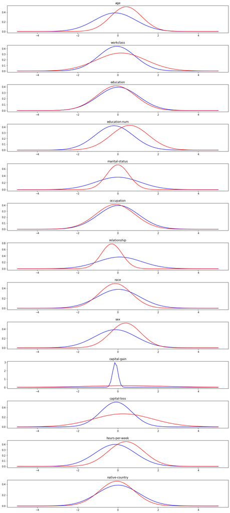

```python
normalized.drop('salary', axis=1, inplace=True)

x = np.linspace(-5, 5, 100)

fig, axs = plt.pyplot.subplots(nrows=13, ncols=1, figsize=(14, 30))
fig.tight_layout(pad=3.0)

index = 0
for column in normalized:
    y1 = sp.stats.norm.pdf(x, lt_mean[column], lt_std[column])
    y2 = sp.stats.norm.pdf(x, mt_mean[column], mt_std[column])

    axs[index].plot(x, y1, label='<= 50', color='blue')
    axs[index].plot(x, y2, label='> 50', color='red')
    axs[index].set_title(column)

    index += 1
```

اینجا بهتر است ویژگی ای را انتخاب کنیم که به گونه ای روی حقوق تاثیر میگذارد.  
به این منظور، باید ویژگی ای پیدا کنیم که pdf دو نمودار به دست آمده برای آن دارای بیشتری تفاوت باشند.  
برای بررسی این موضوع میتوانیم، اختلاف خطوط تقارن و اختلاف بیشترین ارتفاع نمودارها را بررسی نماییم.  
با این بررسی، به نظرم بهترین ویژگی capital-gain خواهد بود. همچنین ویژگی های capital-loss و relationship و sex و age هم به نظر مناسب می آیند. اما ویژگی ذکر شده، از همه تفاوت بیشتری دارد و از آن برای تخمین درآمد استفاده میکنیم.  
همین طور میتوانیم برای تمام این ستون ها میزان دقت را هم محاسبه کنیم تا انتخاب بهتری داشته باشیم.

# سوال دوازدهم

```python
test = pd.read_csv('test.csv')
test
```

|  | age | workclass | fnlwgt | education | education-num | marital-status | occupation | relationship | race | sex | capital-gain | capital-loss | hours-per-week | native-country | salary |
| --- | --- | --- | --- | --- | --- | --- | --- | --- | --- | --- | --- | --- | --- | --- | --- |
| 0 | 25 | Private | 230292 | HS-grad | 9 | Married-civ-spouse | Craft-repair | Husband | White | Male | 0 | 0 | 40 | United-States | <=50K |
| 1 | 36 | Private | 90159 | Bachelors | 13 | Married-civ-spouse | Prof-specialty | Wife | White | Female | 0 | 0 | 32 | United-States | >50K |
| 2 | 40 | Private | 175398 | Assoc-voc | 11 | Divorced | Prof-specialty | Not-in-family | White | Female | 0 | 0 | 20 | United-States | <=50K |
| 3 | 56 | Self-emp-not-inc | 53366 | 11th | 7 | Married-civ-spouse | Craft-repair | Husband | White | Male | 0 | 0 | 20 | United-States | <=50K |
| 4 | 50 | Private | 46155 | Assoc-voc | 11 | Divorced | Prof-specialty | Unmarried | White | Female | 0 | 0 | 40 | United-States | >50K |
| ... | ... | ... | ... | ... | ... | ... | ... | ... | ... | ... | ... | ... | ... | ... | ... |
| 2731 | 27 | Private | 257302 | Assoc-acdm | 12 | Married-civ-spouse | Tech-support | Wife | White | Female | 0 | 0 | 38 | United-States | <=50K |
| 2732 | 40 | Private | 154374 | HS-grad | 9 | Married-civ-spouse | Machine-op-inspct | Husband | White | Male | 0 | 0 | 40 | United-States | >50K |
| 2733 | 58 | Private | 151910 | HS-grad | 9 | Widowed | Adm-clerical | Unmarried | White | Female | 0 | 0 | 40 | United-States | <=50K |
| 2734 | 22 | Private | 201490 | HS-grad | 9 | Never-married | Adm-clerical | Own-child | White | Male | 0 | 0 | 20 | United-States | <=50K |
| 2735 | 52 | Self-emp-inc | 287927 | HS-grad | 9 | Married-civ-spouse | Exec-managerial | Wife | White | Female | 15024 | 0 | 40 | United-States | >50K |

2736 rows × 15 columns

حالا از باقی ستون ها صرف نظر میکنیم و ستون capital-gain را نرمال میکنیم.

```python
test_mean = test['capital-gain'].mean()
test_std = test['capital-gain'].std()
normalized_test = (test['capital-gain'] - test_mean) / test_std

normalized_test
```

```
0      -0.144470
1      -0.144470
2      -0.144470
3      -0.144470
4      -0.144470
          ...
2731   -0.144470
2732   -0.144470
2733   -0.144470
2734   -0.144470
2735    2.286074
Name: capital-gain, Length: 2736, dtype: float64
```

حالا به این صورت عمل میکنیم که ابتدا، دو تا محل تلاقی نمودارهای آبی و قرمز سوال 11 (برای capital-gain) را به دست می آوریم. در ادامه، همان طور که از نمودار هم مشخص است، اگر مقدار capital-gain بین این دو عدد باشد، به احتمال زیادی، درآمد فرد، کم تر از 50 هزار دلار است. در غیر این صورت احتمالا درآمد فرد بیشتر از 50 هزار دلار خواهد بود. (توجه به این که بیشتر داده هایی که در این بین واقع شده اند، آبی رنگ هستند).  
حالا این موضوع را برای تمام داده های فایل text.csv هم بررسی میکنیم و نتیجه را در یک دیتافریم جدید میریزیم.

```python
a = 1/(2*(lt_std['capital-gain']**2)) - 1/(2*(mt_std['capital-gain']**2))
b = mt_std['capital-gain']/(mt_std['capital-gain']**2) - lt_mean['capital-gain']/(lt_std['capital-gain']**2)
c = (lt_mean['capital-gain']**2)/(2*(lt_std['capital-gain']**2)) - (mt_std['capital-gain']**2)/(2*(mt_std['capital-gain']**2)) - np.log(mt_std['capital-gain']/lt_std['capital-gain'])

first_point, second_point = np.roots([a, b, c])

def predict(p):
    if first_point < p and p < second_point:
        return '<=50K'
    else:
        return '>50K'

result = pd.DataFrame()
result['salary'] = normalized_test.apply(predict)

result
```

|  | salary |
| --- | --- |
| 0 | <=50K |
| 1 | <=50K |
| 2 | <=50K |
| 3 | <=50K |
| 4 | <=50K |
| ... | ... |
| 2731 | <=50K |
| 2732 | <=50K |
| 2733 | <=50K |
| 2734 | <=50K |
| 2735 | >50K |

2736 rows × 1 columns

```python
result.to_csv('result.csv')
```